# Intersectional Approach to Covid-19 Vulnerability as a Design Framework for Housing Spatial Decision Support Systems

## 3.3 Racial Segregation in San Francisco.

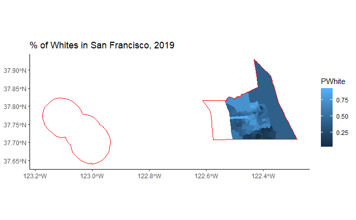

The northern parts of San Francisco City house the greatest concentration of whites. As we move from north to south, the proportion of white households decreases, and non-white households increase. Similar to the maps of New York and Chicago, the city has a clear pattern of concentration of whites and non-whites, signalling the possibility of racial segregation.

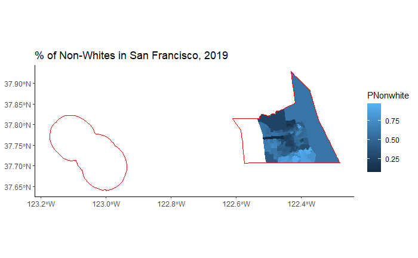

As visible in the map shown above, there is a clear gradient of change of racial concentration from north to south in San Francisco. The southern parts of San Francisco are dominated by non-whites, whereas the northern parts are mostly white in racial composition. The graphs below will break down the composition of non-white population and bear evidence to the segregation that is hinted through the maps above.

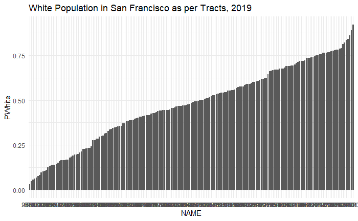

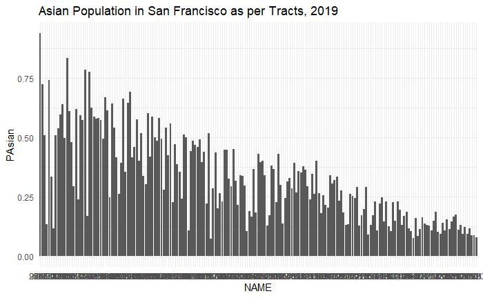

Asians represent the largest minority group residing in San Francisco. As the graph suggests, they mostly reside in census tracts where the population of whites is the least. This shows a clear pattern of segregation across the city, where Asians are pushed to live in neighborhoods where the white population does not reside in good numbers. This is where San Francisco shows a unique intersectional perspective, in that instead of African Americans or Latinos, Asians, who largely participate in the tech Industry are discriminated upon and segregated residentially. In case of San Francisco, they represent a high level of racial vulnerability owing to Covid-19.

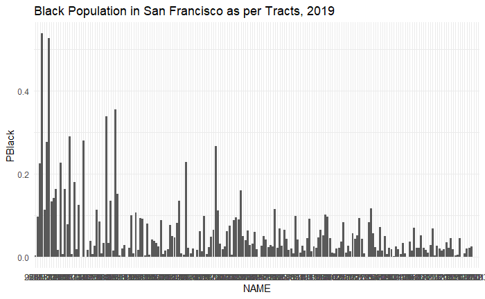

Although the percentage of blacks residing across most census tracts in San Francisco are much lesser than Chicago or New York city, they seem to demonstrate a similar pattern. Blacks or African American households tend to concentrate on places where the white populations are significantly lower. This shows a pattern of residential segregation and spatial vulnerability that is a general concern across all the three cities.

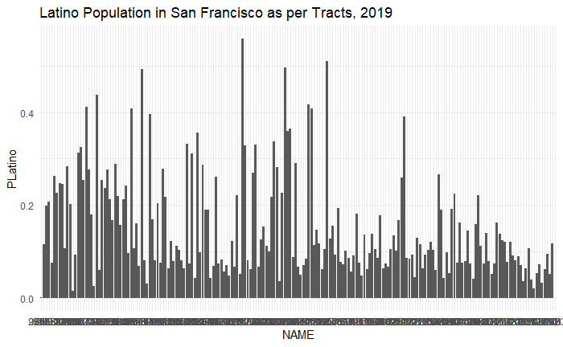

In case of Latinos, the population is more or less distributed across he census tracts where white populations dominate. However, on closer observation it can be noted that the highest number of Latino households are found in the left half of the graph – where the preponderance of white households is the least. Therefore, in case of Latino households there is a possibility of residential segregation, however, it is not as apparent or archetypal as segregation against Asians and blacks in the city of San Francisco.

## 3.4 Measuring Racial Segregation

The racial segregation that was made visible through the above graphs and maps will be quantified in this section through measurements such as dissimilarity, interaction and isolation. they are elaborated below.

### 3.4.1 Dissimilarity

*Dissimilarity* is a common measure of *evenness* between two populations - dissimilarity measures the distribution of a minority population within a majority population. Conceptually, dissimilarity measures the proportion of that minority or subgroup population that would need to move in order to be equally distributed with the majority population. Dissimilarity is calculated as follows:

$D = .5*\sum_i |\frac{b_i}{B}-\frac{w_i}{W}|$

where

$b_i$ is the number of non-white in tract *i*

$B$ is the number of non-white for the county

$w_i$ is the number of whites in tract *i*

$W$ is the number of whites for the city

Dissimilarity between Whites and Non-Whites in Chicago, New York and San Francisco, 2019

| NAME | Dissimilarity |
| --- | --- |
| Chicago | 0.5237355 |
| New York City | 0.5186158 |
| San Francisco | 0.3357396 |

Looking at the three values, the problem of racial segregation is most acute in case of Chicago. The dissimilarity values for both Chicago and New York City are comparable and therefore represent the need for redistribution of minority groups within the majority population. Mitigating this spatial vulnerability would require minority black and latino populations to relocate outside the concentration areas/neighborhoods of their current population. Since the ddimilarity values for San Francisco are less than 50%, it may not be considered for this pattern of residential recovery.

### 3.4.2 Interaction

A second common measure of segregation is *interaction* which is a measure of *exposure*. Interaction measures the likelihood of population subgroups interacting with one another based upon their distribution within areal sub units (tracts). For instance, Non-White-White interaction is calculated as follows:

$Interaction = \sum_i\frac{b_i}{B}*\frac{w_i}{t_i}$

Where

$b_i$ is the Non-white population of tract *i*

$B$ is the Non-White population of the city

$w_i$ is the White population of tract *i*

$t_i$ is the total population of tract *i*

Interaction between Whites and Non-Whites in Chicago, New York and San Francisco, 2019

| NAME | Interaction |
| --- | --- |
| Chicago | 0.3110425 |
| New York City | 0.2838435 |
| San Francisco | 0.3861711 |

The interaction between different groups is highest in case of San Francisco. This corroborates the information gained from the dissimilarity analysis. A possible reason for greater interaction is the fact that Asians (minority populations) often work the same white collar jobs as the majority white population does in San Francisco. New York City, which has the second highest rates of dissimilarity shows the lowest interaction between minority sub groups. This is a cause of archetypal significance in case of new York since it also houses a large population of all racial griups and absence of interaction can be deemed as a major category of housing vulnerability during Covid-19.

### 3.4.3. Isolation

The final measure of racial segregation is *isolation* which is only measured for one group at a time. Isolation measures the likelihood of contact for a subgroup with other subgroup members. It is interpreted similarly to Interaction (as a probability ranging from 0 to 1):

Isolation for Non-Whites

$Isolation = \sum_i\frac{b_i}{B}*\frac{b_i}{t_i}$

Where

$b_i$ is the Non-White population of tract *i*

$B$ is the Non-White population of the city

$t_i$ is the total population of tract *i*

Isolation among Non-Whites in Chicago, New York and San Francisco, 2019

| NAME | Isolation |
| --- | --- |
| Chicago | 0.6889575 |
| New York City | 0.7161565 |
| San Francisco | 0.6138289 |

Similar to the outcomes of interaction, the greatest values for isolation of racial minorities are discovered in New York, shortly followed by Chicago.The values are substantially high for all the three cities, despite the spike in case of New york city - signalling that it is an area of attention for all the cities.

## 3.5 Measuring Income Segregation

This section steers away from the most preponderant model of residential segregation - racial segregation, in order to make a case for an intersectional approach to segregation - income and poverty based segregation. This is done through the use of income ratios, which measures the ratio of median household income at the tract level with median household incomes at the city level. It bears resemblance to the analysis of percentage difference of incomes across racial categories. Maps are designed to understand the landscape of income inequality across the city and relate the same with the geography of racial segregation.

### 3.5.1 Income Segregation in Chicago

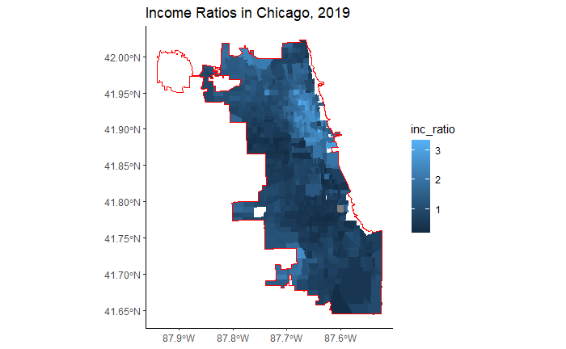

In case of Chicago, highest income ratios can be observed in the northern parts of the city, which roughly coincide with the areas of concentration of white households in the city. Traversing from north to south the incomes decrease.

### 3.5.2 Income Segregation in New York City

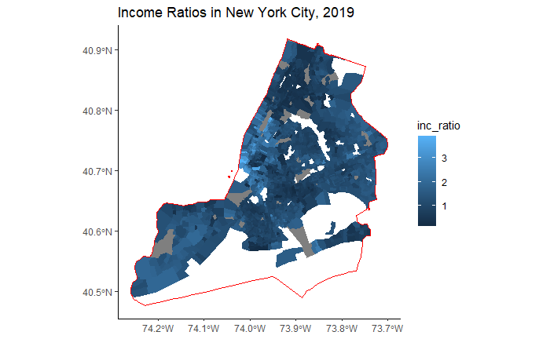

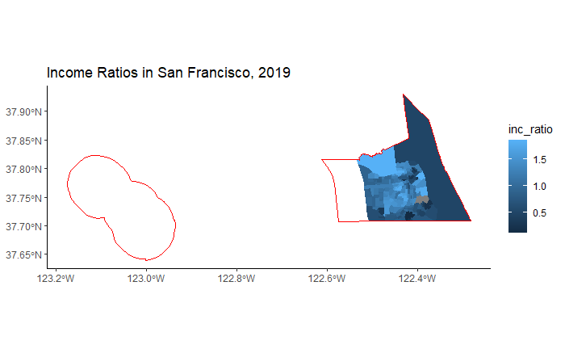

## 3.6 Intersectionality between Income and Racial Segregation

The maps, diagrams and statistical evidence above all bear a relationship between the intersectionality of income and race when it comes to spatial segregaton of vulnerable population groups in the city. In this section, we use scatter plots and line graphs to show the level of intersectionality and its importance for SDSS design for all the three cities.

### 3.6.1. Spatial relationship between Income and Race in Chicago

```
Ignoring unknown parameters: method
```

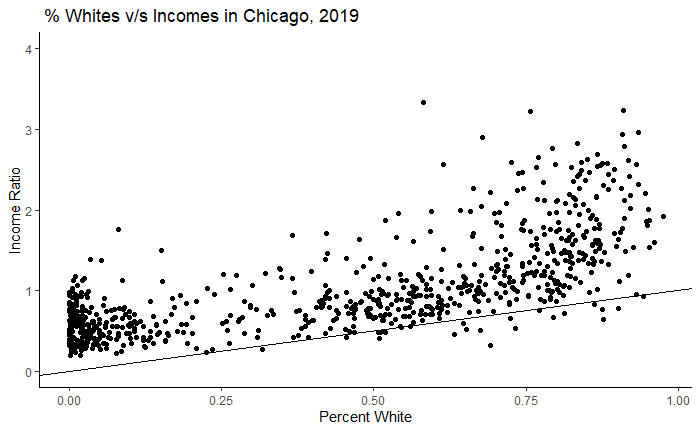

The distribution of counties with lower income ratios (below 1) are concentrated in the left half of the graph where the white population is the lowest. As incomes increase beyond the income ratio of 1, the percentage of white households within the plot also increase. This shows that both income and racial segregation happen together in the city.

### 3.6.2. Spatial relationship between Income and Race in New York City

```
Ignoring unknown parameters: method
```

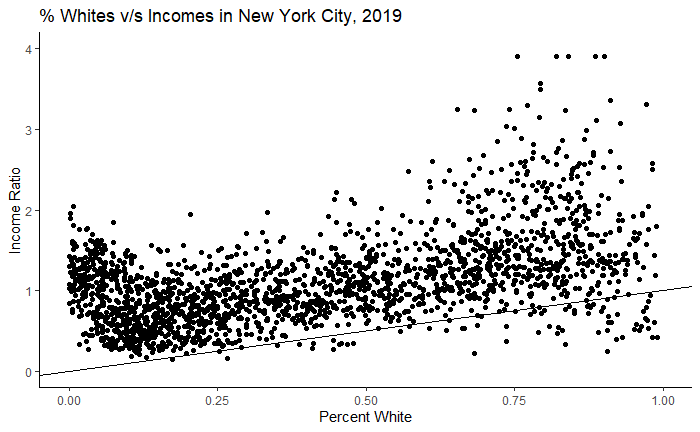

Although in case of New York City, the number of tracts is very large, the highest earning tracts (income ratios >2) are located in areas where the percentage of white population is greater than 50%. This shows a unique vulnerability for the New York city, whereby populations below the income ratio of 2 might represent vulnerable populations residing in racially segregated areas.

### 3.6.3. Spatial relationship between Income and Race in San Francisco

```
Ignoring unknown parameters: method
```

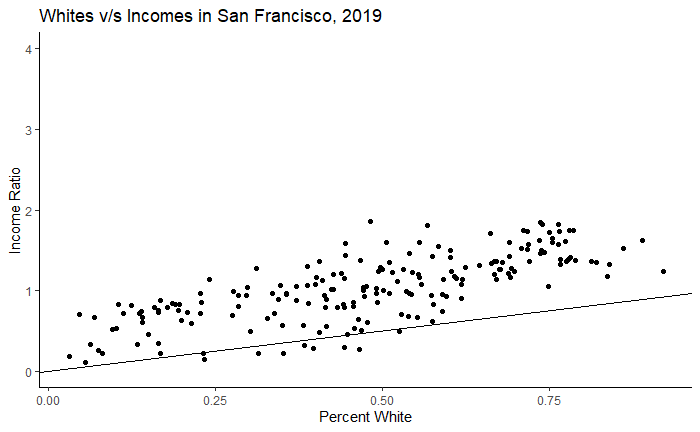

In this section, the number of census tracts are the least, but from the graph, it is clear that the steepness of the graph, is less than other cities, meaning that incomes do not vary as much as other cities do across minorities (especially Asians). Unlike New York, the area of focus cannot be income ratios less than 2 in this case because it encompasses every population group in the city. It would be much better to assume that spatial vulnerability resides in census tracts below the income ratio of 1 and percentage of white population less than 25%.

# 4. Summary

The following table summarises all the intersectional learnings from the above analyses. In the folowing section we will try to have a brief look at some of the demographic and location archetypes based on the above analysis.

| Chicago | New York | San Francisco |
| --- | --- | --- |
|  | Greatest Population Size, Highest Population Density, Greatest number of households belonging to minority populations |  |
| Largest Groups of Racial Minorities – Blacks (29%), Latinos (28%) | Largest Groups of Racial Minorities – Blacks (24%), Latinos (29%) | Largest Groups of Racial Minorities – Asians (34%), Latinos (15%) |
| Largest Vulnerable Age Group – 19 years and below (23%) | Largest Vulnerable Age Group – 19 years and below (22%) | Largest Vulnerable Age Group – 65 years and above (17%) |
|  | Largest number of female headed households |  |
| Black female-Headed Households (57% of total) | Black (41%) and Latina (39%) female headed households | Asian (36%) and Black (33%) female headed households |
|  |  | Extremely high values of Median Household Income (112,449$, 2 times of Chicago and New York) |
| Black Households (MHHI (1-43%)) | Black Households (MHHI (1-24%)) | Black Households – Very Acute Disparity (MHHI (1-70%)) |
|  | Latino Households (MHHI (1-31%)) | Latino Households (MHHI (1-31%)) |
|  |  | Asian Households (MHHI(1-15%)) |
|  | Highest Number of Persons below the Poverty Line |  |
| Poor Persons below the age of 18 (30%) | Poor Persons below the age of 18 (30%) | Poor Persons between the ages 45-64 years (25%), 64 and above (20%) |
|  |  | Males above 45 years of age |
| Higher percentage of Female Poverty (56%) | Higher percentage of Female Poverty (56%) | Higher percentage of Female Poverty (52%) |
| High percentage of poor females below 18 years of age (27%) | High percentage of poor females between 18 and 44 years of age (41%) | High percentage of females above 64 years of age (23%) |
|  | Extremely high number and percentage of renters (67%) | High Proportion of renters (62%) |
| High Proportion of Black Renters (66%) | High Proportion of Latino Renters (83%) | High Proportion of Black Renters (77%) |
| All renters earning less than 35,000 USD (78% burdened) | All renters earning less than 50,000 USD (70% burdened) | All renters earning less than 75,000 USD (52% rent burdened) |

When it comes to understanding segregation as a form of spatial vulnerability, important insights are drawn from the data.It was observed that segregation is primarily against Blacks/African Americans in Chicago, Blacks and Latinos in New York City and against Asians and Blacks in San Francisco.Spatial Vulnerability through Dissimilarity is very high in case of Chicago and New York City (above 0.5) unlike San Francisco. Despite very high population, least interaction can be seen among different racial groups in NYC. New York City also has the greatest preponderance of isolation. Very high income disparity could be seen among the census tracts (based on race) in Chicago and NYC.

# 5. Design Archetypes

From the above analysis, the following design archetypes have been discovered for each city –

Chicago : 1. A 19-year old black female headed household earning <35,000 USD living in rental housing (largest vulnerable group) 2. A 25-year old Latina female headed household living in poverty in rental housing earning 29500$ per year and paying greater than 50% on rent (second largest vulnerable group) 3. A 16 year old black teenage boy, who was employed and lives in rental housing , earning less than 25,000 USD per year, and has recently lost his job (third Largest vulnerable group)

New York : 1. A 35-year old Latina female headed household earning <50,000 USD, comprising two young children (largest vulnerable group) 2. A 20 year old female headed household with 2 or more very young children living in an extremely dense housing stock with her parents as a consequence of doubling down because of the pandemic(second largest vulnerable group) 3. A Latino household who has just the income of one earning member due to the pandemic and is unable to pay rent (third Largest vulnerable group)

San Francisco : 1. A 65-year old married Asian couple, running a small business earning <75,000 USD per year(largest vulnerable group) 2. A black female headed household living in rented housing and paying 60% of income to rent (second largest vulnerable group) 3. A poor Asian female headed household (age above 45 years) suffering from job losses due to the pandemic. (third Largest vulnerable group)

Locational Archetypes – 1. West and South Side Chicago 2. Brooklyn, Bronx and Queens in New York City 3. South East San Francisco/District 10

# 6. Policy Implications

Implications for policy are compared with the normative model of SDSS and presented in the table below.

| Normative Model of Housing Relocation SDSS (Johnson, 2005; Sriraj et. al, 2006) | Covid-19 Model/Housing Recovery SDSS through an intersectional framework (Author, 2021) |
| --- | --- |
| Done with a Policy/programme in Focus | Lack of clear guidelines, lack of direction in the face of a massive impending housing crisis – prepared with a long-term goal of housing recovery for vulnerable populations in mind |
| Housing Clients of the Voucher Program deemed as clients | Identification of vulnerable groups across different cities through creation of a heterogeneous vulnerability index as clients |
| Localised in the needs of a single city – operationalised at a time of normalcy | Tries to understand the unique positionality of a city during a nationwide pandemic – operationalised during times of an emergency |
| Uses a simple model of multi-criteria decision-making model to identify suitable locations for housing | Uses a multi-layered model of multi-criteria decision-making model to identify suitable locations for housing |
| Assumes that the location of a nearby facility equates provision of amenities | Utilizes big data to inform the user of the nature of facility at a location (whether it is functional, nearing foreclosure, etc.) to determine access to infrastructure (particularly health) |
| Assumes scalability and reproducibility | Demonstrates the unique vulnerability of populations across different cities – different clients, different needs, different design inputs |

# 7. Scope and Limitations

The research is a simplistic model of an intersectional analysis. Some of the major limitations of the research are the lack of data variety, because only a single source of data is taken. Although effort has been made to distinguish different cities based on their overall criteria, a more nuanced analysis would entail examining and organising data at the census tract or block level. Not much special effort was made to make the data relevant to the time frame of the Covid-19 pandemic. Data from more current times could add significant insights. Moreover, time series data would enable trend analysis of vulnerability across time. A more robust spatio temporal analytics approach would lend important insights to the body of research presented here. The scope of this research was limited to an overarching view of different vulnerabilities across cities in the US during a global pandemic. To a certain extent, a general idea has been presented towards the same, and the overarching goal has been reached.

# 8. Areas of Future Research

An intersectional analysis of housing instability taking cognizance of more accurate data sets and more advanced models of spatial analytics is the next step towards this project. This area will be explored through an independent research project over Summer 2021, under the guidance of Prof. Andrew Greenlee.

# 9. Acknowledgements

I am grateful for the advice and guidance offered by Prof. Andrew Greenlee that led to the successful completion of this project. I am also very grateful to all my peers at the UP 494 course, particularly Asha Barnes, who took the time to help me prepare for my project and sharpen the intersectional lens thread that runs throughout the research.

# References

Cunningham, M. K., Hariharan, A. & Fiol, O., 2020. The Looming Eviction Cliff: Findings from the Urban Institute Coronavirus Tracking Survey, s.l.: Urban Institute.

Johnson, M. P., 2001. Decision Support for Family Relocation Decisions under Section 8 Housing Assistance Program using Geographic Information Systems and the Analytical Hierarchy Process. Journal of Housing Research, 12(2), pp. 277-306.

Johnson, M. P., 2005. Spatial decision support for assisted housing mobility counseling. Decision Support Systems, Volume 41, pp. 296-312.

Khanijahani, A. & Tomassoni, L., 2021. Socioeconomic and Racial Segregation and COVID-19: Concentrated Disadvantage and Black Concentration in Association with COVID-19 Deaths in the USA. Journal of racial and Ethnic Health Disparities, pp. 1-9.

Layser, D. M. et al., 2020. Mitigating Housing Instability During a Pandemic. University of Illinois College of Law Legal Studies Research Paper, 20(15), pp. 1-74.

Luhmann, S., 2020. Consider This: COVID-19 Makes Intersectional Research Urgent, Alberta: University of Alberta.

Sriraj, P., Minor, M. & Thakuriah, P. V., 2006. Impact of Information on Housing Relocation using Analytical Hierarchy Process and Interactive GIS. Applications of Advanced Technology in Transportation, pp. 816-821.